# Bloque 2: Probabilidad y probabilidad condicional mediante simulaciones

Explorando el azar con R

Author

Taller de programación, simulación y probabilidad

# ¿Qué haremos en este bloque?

En el bloque anterior usamos R para simular monedas y dados, contar resultados y construir gráficos.

En este bloque usaremos esas herramientas para explorar tres ideas centrales:

- probabilidad como frecuencia relativa;
- probabilidad condicional como cambio de información;
- simulación como herramienta para resolver problemas contraintuitivos.

También trabajaremos con una situación famosa: el problema de Monty Hall.

**Idea central**

Una simulación no reemplaza el razonamiento matemático, pero nos ayuda a explorar, descubrir patrones y poner a prueba nuestra intuición.

# 1. Probabilidad como frecuencia relativa

Comencemos con una moneda. Si la moneda es equilibrada, esperamos que la probabilidad de Cara sea cercana a 0.5.

Simulemos 1000 lanzamientos.

```r
lanzamientos <- sample(c("Cara", "Sello"),
                       size = 1000,
                       replace = TRUE)

mean(lanzamientos == "Cara")
```

```
[1] 0.511
```

La instrucción `mean(lanzamientos == "Cara")` calcula la proporción de veces que apareció Cara.

**Para pensar**

- ¿El resultado fue exactamente 0.5?
- ¿Debería ser exactamente 0.5?
- ¿Qué crees que ocurrirá si hacemos 10000 lanzamientos?

Visualicemos la evolución de esta proporción.

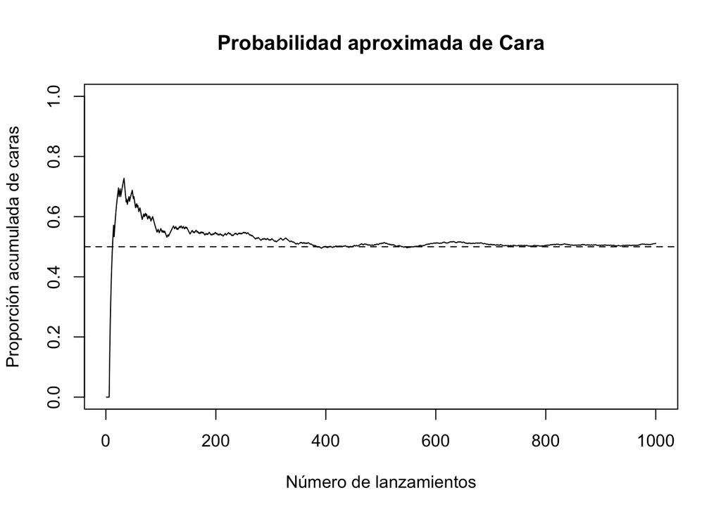

```r
proporcion_caras <- cumsum(lanzamientos == "Cara") / 1:1000

plot(proporcion_caras,
     type = "l",
     ylim = c(0, 1),
     xlab = "Número de lanzamientos",
     ylab = "Proporción acumulada de caras",
     main = "Probabilidad aproximada de Cara")

abline(h = 0.5, lty = 2)
```

# 2. Probabilidades con un dado

Ahora estudiemos eventos asociados al lanzamiento de un dado.

Simulemos 10000 lanzamientos.

```r
dado <- sample(1:6,
               size = 10000,
               replace = TRUE)
```

## Evento: obtener un número mayor o igual que 5

```r
mean(dado >= 5)
```

```
[1] 0.3385
```

Este código aproxima la probabilidad de obtener 5 o 6.

Teóricamente, esta probabilidad es:

```r
2 / 6
```

```
[1] 0.3333333
```

**Para discutir**

- ¿La simulación entrega exactamente el mismo resultado que el cálculo teórico?
- ¿Por qué son parecidos?
- ¿Por qué no son necesariamente idénticos?

## Gráfico de barras de los resultados

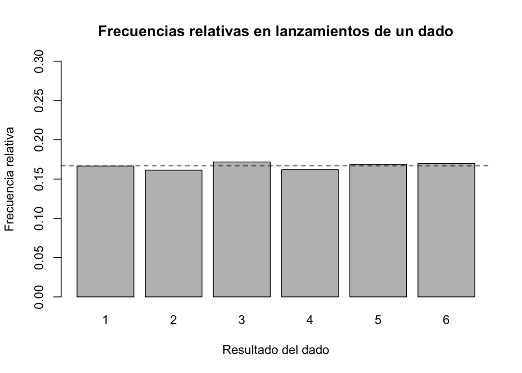

```r
frecuencias <- table(factor(dado, levels = 1:6)) / length(dado)

barplot(frecuencias,
        ylim = c(0, 0.3),
        xlab = "Resultado del dado",
        ylab = "Frecuencia relativa",
        main = "Frecuencias relativas en lanzamientos de un dado")

abline(h = 1/6, lty = 2)
```

# 3. Dos dados: eventos combinados

Ahora vamos a simular el lanzamiento de dos dados.

```r
dado1 <- sample(1:6,
                size = 10000,
                replace = TRUE)

dado2 <- sample(1:6,
                size = 10000,
                replace = TRUE)

suma <- dado1 + dado2
```

Veamos algunos resultados.

```r
head(data.frame(dado1, dado2, suma))
```

```
  dado1 dado2 suma
1     3     6    9
2     3     3    6
3     1     4    5
4     6     5   11
5     5     1    6
6     4     6   10
```

## Evento A: la suma es al menos 10

```r
mean(suma >= 10)
```

```
[1] 0.1685
```

Visualicemos la distribución de la suma.

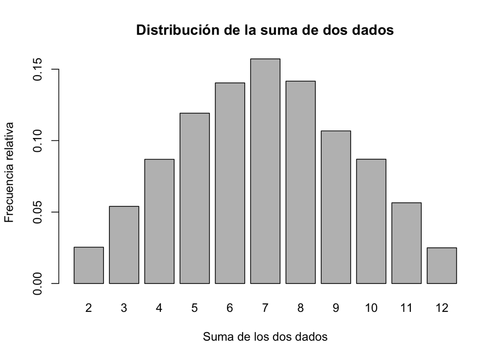

```r
barplot(table(factor(suma, levels = 2:12)) / length(suma),
        xlab = "Suma de los dos dados",
        ylab = "Frecuencia relativa",
        main = "Distribución de la suma de dos dados")
```

**Para observar**

- ¿Todas las sumas son igualmente probables?
- ¿Qué suma aparece con mayor frecuencia?
- ¿Por qué crees que ocurre eso?

# 4. ¿Qué significa condicionar?

La probabilidad condicional aparece cuando calculamos una probabilidad usando información adicional.

Por ejemplo, podemos preguntar:

> ¿Cuál es la probabilidad de que la suma sea al menos 10?

Pero también podemos preguntar:

> ¿Cuál es la probabilidad de que la suma sea al menos 10 si sabemos que el primer dado fue 6?

La segunda pregunta usa más información.

**Idea clave**

Condicionar significa mirar solo los casos que cumplen cierta condición.

# 5. Probabilidad sin información adicional

Primero calculemos la probabilidad de que la suma sea al menos 10.

```r
mean(suma >= 10)
```

```
[1] 0.1685
```

# 6. Probabilidad usando información adicional

Ahora miremos solo los casos donde el primer dado fue 6.

```r
casos_dado1_es_6 <- dado1 == 6
```

Calculemos la probabilidad de que la suma sea al menos 10 dentro de esos casos.

```r
mean(suma[casos_dado1_es_6] >= 10)
```

```
[1] 0.5106383
```

Otra forma equivalente es:

```r
sum((suma >= 10) & (dado1 == 6)) / sum(dado1 == 6)
```

```
[1] 0.5106383
```

**Para pensar**

- ¿Esta probabilidad es igual a la anterior?
- ¿Por qué cambia?
- ¿Qué información nueva estamos usando?

# 7. Visualización de probabilidad condicional

Queremos ver cómo cambia la probabilidad de que la suma sea al menos 10 según el valor del primer dado.

```r
prob_por_dado1 <- tapply(suma >= 10, dado1, mean)

prob_por_dado1
```

```
        1         2         3         4         5         6
0.0000000 0.0000000 0.0000000 0.1755725 0.3321678 0.5106383
```

Ahora hacemos un gráfico.

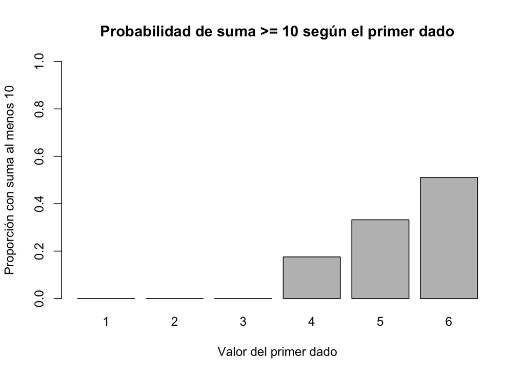

```r
barplot(prob_por_dado1,
        ylim = c(0, 1),
        xlab = "Valor del primer dado",
        ylab = "Proporción con suma al menos 10",
        main = "Probabilidad de suma >= 10 según el primer dado")
```

**Interpretación**

El gráfico muestra que la probabilidad de obtener una suma grande no es la misma para todos los valores del primer dado. Saber el resultado del primer dado cambia nuestra información.

# 8. Comparación visual: probabilidad general vs probabilidad condicional

Podemos comparar la probabilidad general con la probabilidad condicional dado que el primer dado fue 6.

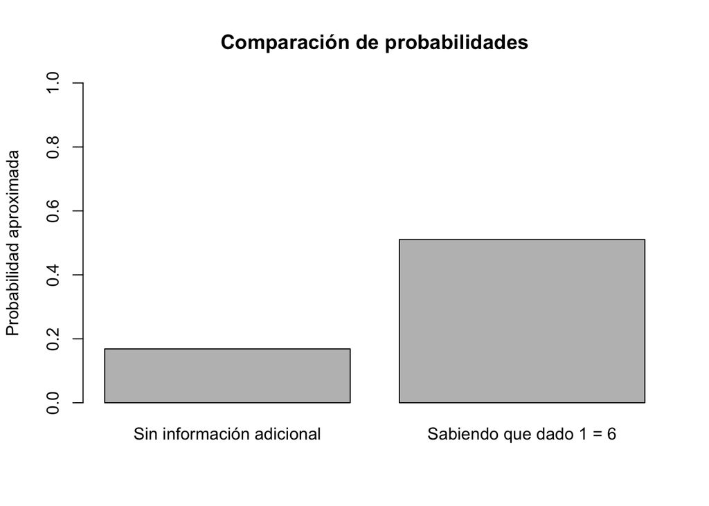

```r
prob_general <- mean(suma >= 10)
prob_condicional <- mean(suma[dado1 == 6] >= 10)

comparacion <- c("Sin información adicional" = prob_general,
                 "Sabiendo que dado 1 = 6" = prob_condicional)

barplot(comparacion,
        ylim = c(0, 1),
        ylab = "Probabilidad aproximada",
        main = "Comparación de probabilidades")
```

**Para discutir**

¿Por qué la segunda barra es más alta?

# 9. Otra visualización: espacio de casos

También podemos construir una tabla que muestre cuántos casos cumplen o no cumplen el evento, según el valor del primer dado.

```r
tabla_condicional <- table("Primer dado" = dado1,
                           "Suma >= 10" = suma >= 10)

tabla_condicional
```

```
           Suma >= 10
Primer dado FALSE TRUE
          1  1622    0
          2  1666    0
          3  1695    0
          4  1404  299
          5  1146  570
          6   782  816
```

Ahora visualizamos proporciones por fila. Es decir, dentro de cada valor del primer dado, miramos qué proporción cumple el evento.

[figure not shown]

```r
barplot(prop.table(tabla_condicional, margin = 1),
        beside = TRUE,
        legend.text = c("No", "Sí"),
        ylim = c(0, 1),
        xlab = "Valor del primer dado",
        ylab = "Proporción",
        main = "Dentro de cada valor del primer dado")
```

**Lo importante**

En probabilidad condicional, no usamos todos los casos. Usamos solo los casos que cumplen la condición.

# 10. Actividad guiada

Modifica el código anterior para estudiar otras preguntas:

1. ¿Cuál es la probabilidad de que la suma sea 7?
2. ¿Cuál es la probabilidad de que la suma sea 7 si el primer dado fue 3?
3. ¿Cuál es la probabilidad de que el segundo dado sea par si la suma fue mayor que 8?

Puedes usar estas líneas como base:

```r
mean(suma == 7)
```

```
[1] 0.1572
```

```r
mean(suma[dado1 == 3] == 7)
```

```
[1] 0.1669617
```

```r
mean(dado2[suma > 8] %% 2 == 0)
```

```
[1] 0.5891754
```

# 11. Un problema contraintuitivo: Monty Hall

Ahora veremos un problema famoso donde la intuición suele fallar.

Imagina un concurso con tres puertas:

- detrás de una puerta hay un premio;
- detrás de las otras dos no hay premio;
- eliges una puerta;
- el animador, que sabe dónde está el premio, abre una puerta sin premio;
- luego te ofrece cambiar tu elección.

La pregunta es:

> ¿Conviene cambiar de puerta o quedarse con la elección inicial?

**Antes de simular**

Vota una opción:

- Conviene quedarse.
- Conviene cambiar.
- Da lo mismo.

Explica brevemente por qué.

# 12. Simulación de Monty Hall

Primero creamos una función que simula un juego.

```r
jugar_monty_hall <- function(cambiar = TRUE) {

  puertas <- 1:3

  premio <- sample(puertas, size = 1)
  eleccion_inicial <- sample(puertas, size = 1)

  puertas_para_abrir <- puertas[puertas != premio & puertas != eleccion_inicial]
  puerta_abierta <- sample(puertas_para_abrir,
                           size = 1,
                           replace = FALSE)

  puertas_para_elegir <- puertas[puertas != eleccion_inicial &
                                   puertas != puerta_abierta]

  if (cambiar) {
    eleccion_final <- puertas_para_elegir[1]
  } else {
    eleccion_final <- eleccion_inicial
  }

  eleccion_final == premio
}
```

Probemos un juego cambiando de puerta.

```r
jugar_monty_hall(cambiar = TRUE)
```

```
[1] FALSE
```

Probemos un juego sin cambiar de puerta.

```r
jugar_monty_hall(cambiar = FALSE)
```

```
[1] FALSE
```

# 13. Repetimos muchas veces

Ahora repetimos el juego 10000 veces para comparar ambas estrategias.

```r
resultados_cambiar <- replicate(10000, jugar_monty_hall(cambiar = TRUE))
resultados_quedarse <- unlist(replicate(10000, jugar_monty_hall(cambiar = FALSE)))

prob_cambiar <- mean(resultados_cambiar)
prob_quedarse <- mean(resultados_quedarse)

prob_cambiar
```

```
[1] 0.4751
```

```r
prob_quedarse
```

```
[1] 0.3371
```

Visualicemos los resultados.

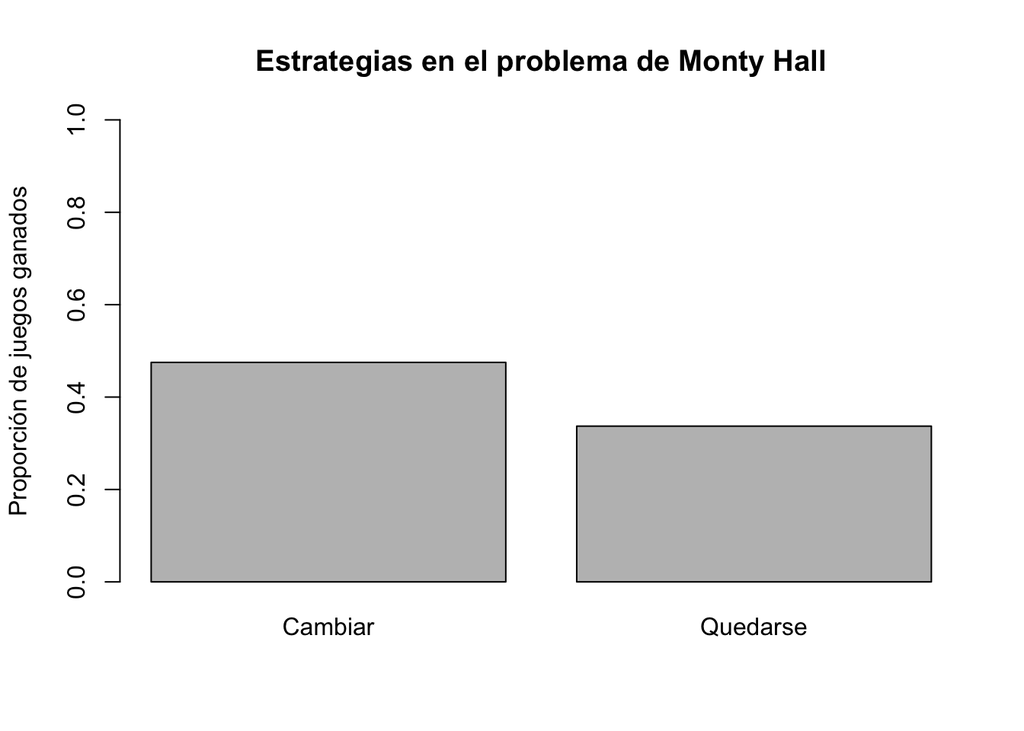

```r
comparacion_monty <- c("Cambiar" = prob_cambiar,
                       "Quedarse" = prob_quedarse)

barplot(comparacion_monty,
        ylim = c(0, 1),
        ylab = "Proporción de juegos ganados",
        main = "Estrategias en el problema de Monty Hall")
```

**Para discutir**

- ¿Qué estrategia ganó más veces?
- ¿El resultado coincide con tu intuición inicial?
- ¿Por qué la simulación puede ayudarnos en problemas contraintuitivos?

# 14. Evolución de las estrategias en Monty Hall

También podemos mirar cómo evoluciona la proporción de triunfos a medida que repetimos el juego.

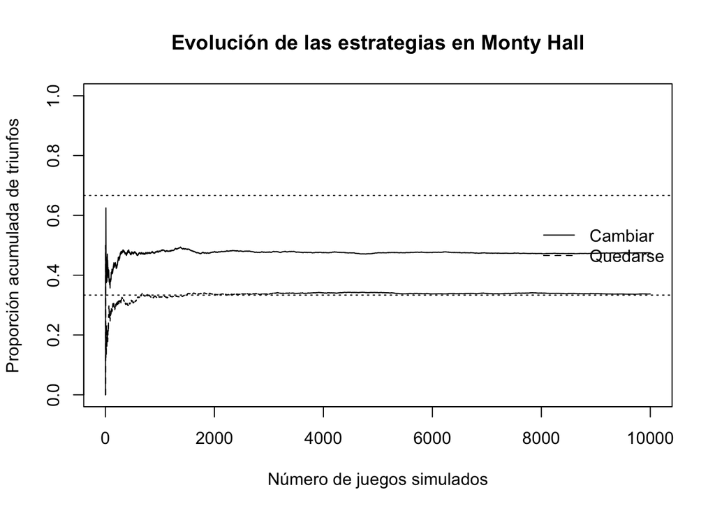

```r
evolucion_cambiar <- cumsum(resultados_cambiar) / 1:10000
evolucion_quedarse <- cumsum(resultados_quedarse) / 1:10000

plot(evolucion_cambiar,
     type = "l",
     ylim = c(0, 1),
     xlab = "Número de juegos simulados",
     ylab = "Proporción acumulada de triunfos",
     main = "Evolución de las estrategias en Monty Hall")

lines(evolucion_quedarse, lty = 2)
abline(h = 2/3, lty = 3)
abline(h = 1/3, lty = 3)
legend("right",
       legend = c("Cambiar", "Quedarse"),
       lty = c(1, 2),
       bty = "n")
```

# 15. Cierre del bloque

En este bloque usamos simulaciones para explorar probabilidades.

Aprendimos que:

- una probabilidad puede aproximarse mediante una proporción;
- al repetir muchas veces un experimento, aparecen patrones;
- la probabilidad condicional cambia el conjunto de casos que estamos mirando;
- los gráficos ayudan a entender cómo cambia una probabilidad cuando tenemos más información;
- la simulación puede ayudarnos a resolver problemas donde la intuición no basta.

**Mensaje final**

Programar nos permite experimentar con ideas matemáticas. En vez de solo imaginar qué podría ocurrir, podemos simularlo, visualizarlo y discutirlo.

# 16. Desafío final opcional

Modifica la simulación de Monty Hall para hacer 1000 juegos en lugar de 10000.

Luego responde:

- ¿Los resultados son más variables?
- ¿Cuál estrategia sigue siendo mejor?
- ¿Qué ocurre si repites la simulación varias veces?